# Live Session Unit 2 Assignment

Camille Howard

September 8, 2018

#### **What is a basic workflow for reproducible research?**

1. Data Gathering
2. Data Analysis
3. Results Presentation

#### **What are five practical tips for making research reproducible?**

1. Document everything
2. Everything is a text file.
3. All files should be human readable
4. Explicitly tie your files together.
5. Have a plan to organize, store and make your files available.

#### **Give an example of how you might implement each tip**

1. Recording session info and note what system is used. This allows people to know what packages are loaded just by looking at the code.
2. Files should be stored in the simplest file format, text file.
3. Comment on your code with a goal of communicating its design and purpose.
4. Use tie commands to explicitly link files together. These commands instruct the program you are using to use information from another file.
5. Organizing the research in files to limit the amount of content any one file has to make files modular.

#### **Which of these do you think will be the most difficult**

I’m concerned about creating a plan to organize, store and make files available. It seem like there are a lot of different files and the propensity for the information to get lost is highly probably if there isn’t a good organization plan in place.

#### We will be using the built-in dataset airquality which has daily air quality.

*2A. Temperature By Month scatterplot shows monthly temperature.* 2B. Temperature Vs Ozone scatterplot shows Ozone activity in relation to temperature.

```r
str(airquality)
```

```
## 'data.frame':    153 obs. of  6 variables:
##  $ Ozone  : int  41 36 12 18 NA 28 23 19 8 NA ...
##  $ Solar.R: int  190 118 149 313 NA NA 299 99 19 194 ...
##  $ Wind   : num  7.4 8 12.6 11.5 14.3 14.9 8.6 13.8 20.1 8.6 ...
##  $ Temp   : int  67 72 74 62 56 66 65 59 61 69 ...
##  $ Month  : int  5 5 5 5 5 5 5 5 5 5 ...
##  $ Day    : int  1 2 3 4 5 6 7 8 9 10 ...
```

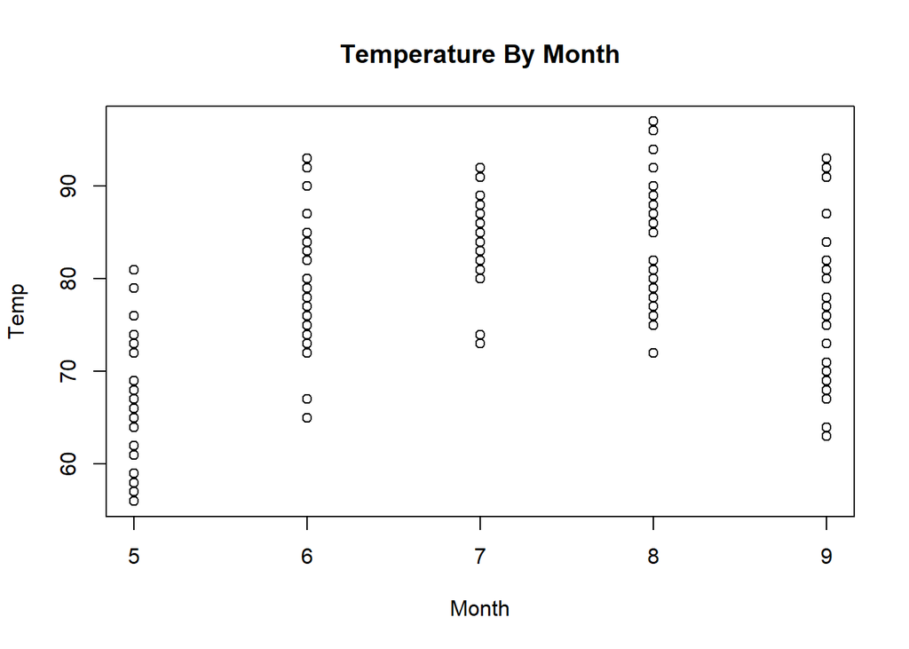

```r
Temp <- airquality$Temp
Month <- airquality$Month
plot(x=Month, y=Temp, main="Temperature By Month")
```

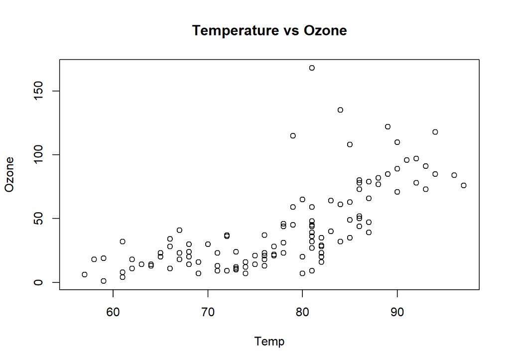

```r
Ozone <- airquality$Ozone
plot(x=Temp, y=Ozone, main="Temperature vs Ozone")
```

*3A. Scatterplot temperature vs pressure.

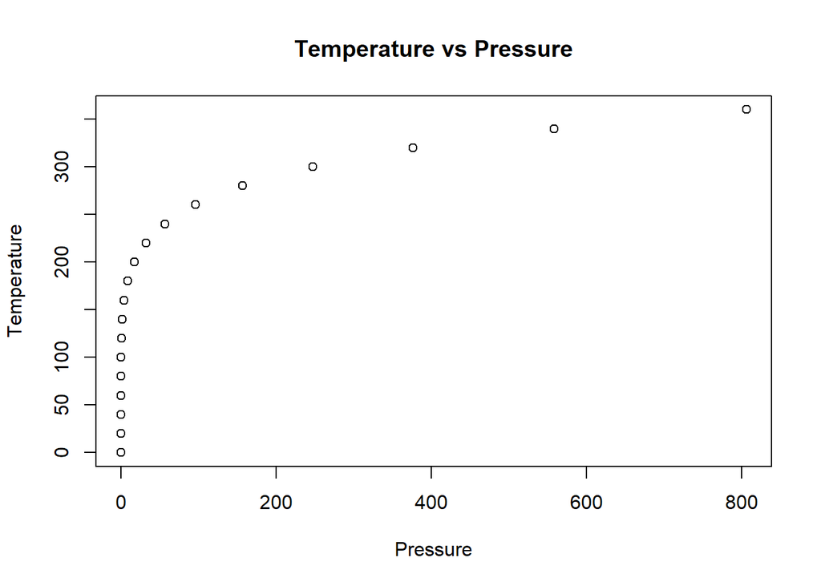

```r
Pressure <-pressure$pressure
Temperature <-pressure$temperature
plot(x=Pressure, y=Temperature, main="Temperature vs Pressure")
```

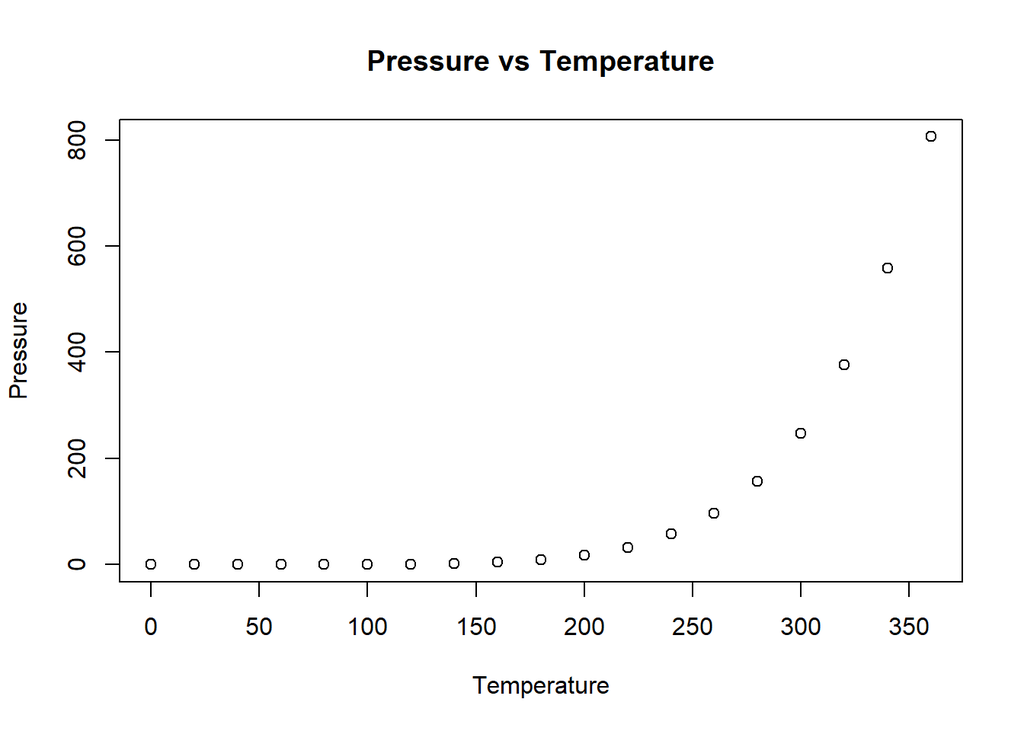

```r
Temperature <-pressure$temperature
Pressure <-pressure$pressure
plot(x=Temperature, y=Pressure, main="Pressure vs Temperature")
```